# Statics: solving of ODEs II

## E5.a - Task

[figure not shown]

- **given:**
  - $L_1 = 300mm, L_2 = 301mm, A = 10mm^2, E = 210000MPa, \alpha = 12 \cdot 10^{-6} K^{-1}$
- **wanted:**
  - Necessary heat $\Delta T$ that the rod can be connected to support B
  - Stress $\sigma$ after cool-down
- **procedure:**
  - use: $\frac{du}{dx} = \frac{N(x)}{E\,A} + \alpha \, \Delta T$
- **pseudo-code**:

Note

Do this task inside a jupyter notebook!

```
clear variables

import sympy as sp
import ...

# define symbols
..., ..., ... = sp.symbols(...)

# define the deformation equation
... = sp.Eq(..., ...)

# solve the ODE
... = sp.dsolve(..., ...)

# determine the necessary temperature
... = sp.solve(..., ...)

# Calculate the resulting stress
... = sp.dsolve(..., ...)
## determine N(x)
... = sp.solve(..., ...)

sigma = ...

# Interpret your result.
```

# E5.A - Task

```python
reset -f
```

```python
import sympy as sp
import numpy as np
import matplotlib.pyplot as plt

from IPython.display import Math, Latex
```

## Definition of variables

```python
L1, L2, A, E, alpha, dT, x, N, dTc = sp.symbols('L1, L2, A, E, alpha, dT, x, N, dTc', real = 'True')
```

```python
u = sp.Function('u')
```

## Definition of deformation equation

The part of the equation regarding the temprature influence must be positive "+" because the system gets heated.

```python
eq = sp.Eq(sp.diff(u(x),x), N/(E*A) + alpha*dT)
```

## Solution of the ODE

```python
sol = sp.dsolve(eq, ics = {u(0):0})
u = sp.simplify(sol.rhs)
```

```python
u = sp.simplify(u.subs([(N,0),(x,L1)]))
```

## Determine the necessary temperature

```python
eq1 = sp.Eq(L2-L1, u)
sol = sp.solve(eq1, dT)
dT = sol[0]
dT
```

$\displaystyle \frac{- L_{1} + L_{2}}{L_{1} \alpha}$

```python
round(dT.subs([(L1, 300), (L2, 301), (alpha, 12*10**(-6))]))
```

$\displaystyle 278$

## Calculate the resulting stress after the rod is fixed and cold

If the rod got cold, temperature is decreasing, and therfore, the temperature part of the euqation gets a negative "-" sign.

```python
u = sp.Function('u')
eq = sp.Eq(sp.diff(u(x),x), N/(E*A) - alpha*dTc)
sol = sp.dsolve(eq, ics = {u(0):0})
u = sp.simplify(sol.rhs)
```

```python
eq1 = sp.Eq(0, u.subs(x,L2))
sol = sp.solve(eq1,N)
N = sol[0]
```

```python
sigma = N / A
sigma
```

$\displaystyle E \alpha dTc$

Since the stress is positive, it means that there is tension which makes sense. A to short beam gets pulled to be fixed in a bearing.

## E5.b - Task

[figure not shown]

Note

Do this task inside a jupyter notebook!

```
clear variables

import sympy as sp
import ...

# define symbols
..., ..., ... = sp.symbols(...)

# determine internal force equilibrium
... = sp.Eq(..., ...)

# Definition of the deformation equation
... = sp.Eq(sp.Derivative(..., ...), ...)

# Solution of the ODE with BC
... = sp.dsolve(..., ...)

# Calculate temperature in order to compensate length change of the rod
... = sp.Eq(..., ...)
... = sp.solve(..., ...)

# Get resulting deformation equation

# Get resulting Stress equation

# Plot results
... = sp.lambdify(..., ..., 'numpy')
plt.plot(..., ...)
```

# E5.B - Task

```python
reset -f
```

```python
import sympy as sp
import numpy as np
import matplotlib.pyplot as plt

from IPython.display import Math, Latex
```

## Definition of variables

```python
F, g, A, L, rho, alpha, E, dT, x, N = sp.symbols('F, g, A, L, rho, alpha, E, dT, x, N', real = 'True')
```

```python
u = sp.Function('u')
N = sp.Function('N')
```

## Determine internal force equilibrium

```python
eq = sp.Eq(0, -N(x) + F + rho*A*g*(L-x))
sol = sp.solve(eq, N(x))
N = sol[0]
N
```

$\displaystyle A L g \rho - A g \rho x + F$

## Definition of deformation equation

```python
eq = sp.Eq(sp.Derivative(u(x),x), N/(E*A) + alpha*dT)
eq
```

$\displaystyle \frac{d}{d x} u{\left(x \right)} = \alpha dT + \frac{A L g \rho - A g \rho x + F}{A E}$

## Solution of the ODE

```python
sol = sp.dsolve(eq, ics = {u(0):0})
u = sp.simplify(sol.rhs)
sol
```

$\displaystyle u{\left(x \right)} = \alpha dT x + \frac{L g \rho x}{E} - \frac{g \rho x^{2}}{2 E} + \frac{F x}{A E}$

## Compensate length change of the rod due to temperature

```python
eq1 = sp.Eq(0, u.subs(x,L))
sol = sp.solve(eq1, dT)
dTnew = sp.expand(sol[0])
dTnew
```

$\displaystyle - \frac{L g \rho}{2 E \alpha} - \frac{F}{A E \alpha}$

## Deformation

```python
u = sp.simplify(u.subs(dT, dTnew))
display(u)
```

$\displaystyle \frac{g \rho x \left(L - x\right)}{2 E}$

## Stress

```python
eq = sp.Eq(dT, dTnew)
sol = sp.solve(eq, F)
Fn = sol[0]
sigma = N.subs(F, Fn) / A
sp.simplify(sigma)
```

$\displaystyle - E \alpha dT + \frac{L g \rho}{2} - g \rho x$

## Plotting

```python
u = u.subs([(F, 10), (g, 9810), (A, 4), (L, 100), (rho, 7.85e-6), (alpha, 12e-6), (E, 210000)])
sigma = sigma.subs([(dT, -1), (g, 9810), (A, 4), (L, 100), (rho, 7.85e-6), (alpha, 12e-6), (E, 210000)])
```

```python
u_fun = sp.lambdify((x), u, 'numpy')
sigma_fun = sp.lambdify((x), sigma, 'numpy')
s = np.arange(0,101,1)
```

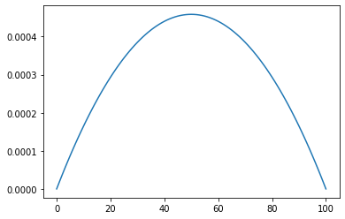

```python
plt.plot(s, u_fun(s))
```

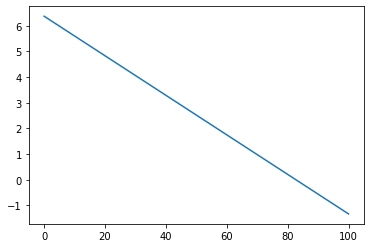

```python
plt.plot(s, sigma_fun(s))
```